# 保有比率

アセット･マネジメント･コンサルティング株式会社 http://am-consulting.co.jp

```
## Title : 資金循環 - 国債・財投債合計(ストック)に対する日本銀行と海外の保有比率時系列推移 - 四半期 - 2016年7-9月期
## Raw Data Source : 日本銀行
## Author : アセット･マネジメント･コンサルティング株式会社 http://am-consulting.co.jp
## 作成日 : 2016-10-05 14:10:08
## 特記 : 複数のワードで検索する際は半角スペースで区切ってください
## 特記 : 表中、-9999はNAを意味します
## ID : 20161005141007
```

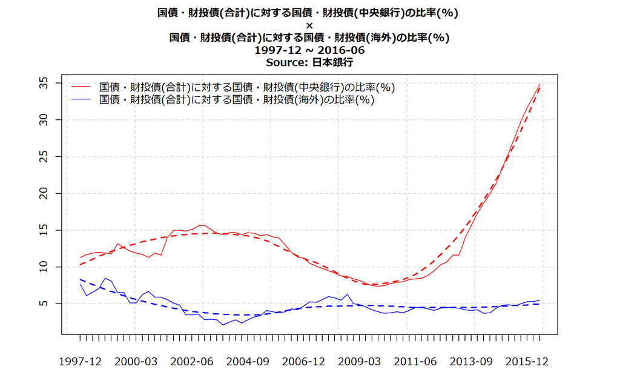

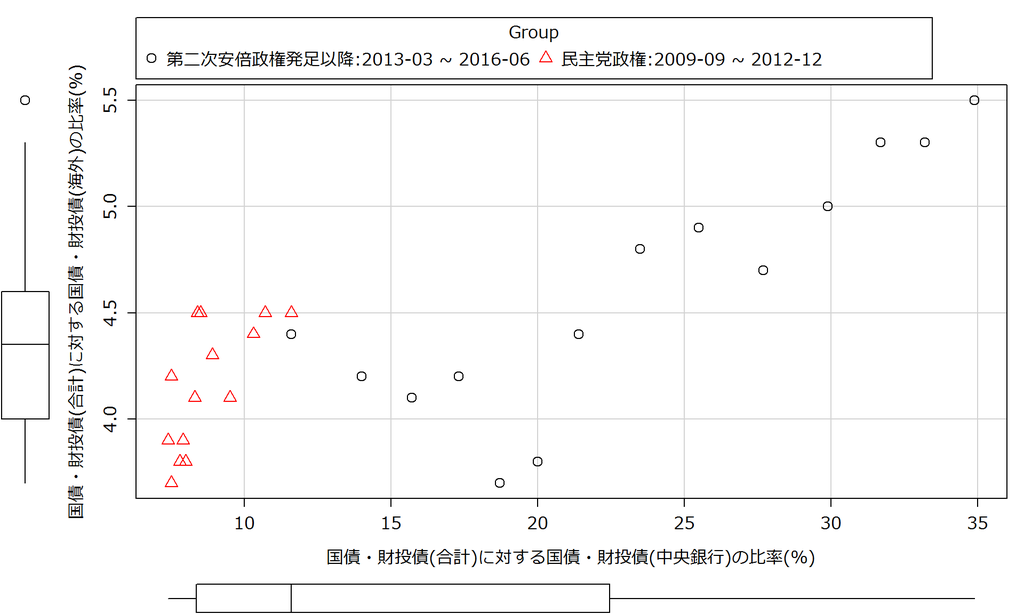

**資金循環 - 国債・財投債合計(ストック)に対する日本銀行と海外の保有比率時系列推移 - 四半期 - 2016年7-9月期 1997-12~2016-06 . Powered By https://www.amcharts.com/**

[interactive chart not shown]

**資金循環 - 国債・財投債合計(ストック)に対する日本銀行と海外の保有比率時系列推移 - 四半期 - 2016年7-9月期 1997-12~2016-06 . Powered By https://www.amcharts.com/**

[interactive chart not shown]

**資金循環 - 国債・財投債合計(ストック)に対する日本銀行と海外の保有比率時系列推移 - 四半期 - 2016年7-9月期 1997-12~2016-06 . Powered By https://www.amcharts.com/**

[interactive chart not shown]

**資金循環 - 国債・財投債合計(ストック)に対する日本銀行と海外の保有比率時系列推移 - 四半期 - 2016年7-9月期 1997-12~2016-06 . Powered By https://www.amcharts.com/**

[interactive chart not shown]

**資金循環 - 国債・財投債合計(ストック)に対する日本銀行と海外の保有比率時系列推移 - 四半期 - 2016年7-9月期 1997-12~2016-06 . Powered By https://www.amcharts.com/**

[interactive chart not shown]

**原系列 / Original**

| Date | 資産・－国債・財投債／中央銀行／ストック(兆円) | 資産・－国債・財投債／海外／ストック(兆円) | 資産・－国債・財投債／合計／ストック(兆円) | 国債・財投債(合計)に対する国債・財投債(中央銀行)の比率(%) | 国債・財投債(合計)に対する国債・財投債(海外)の比率(%) | Prime Minister of Japan |
| --- | --- | --- | --- | --- | --- | --- |
| 1997-12 | 32.9827 | 22.447 | 291.3786 | 11.3 | 7.7 | Ryutaro Hashimoto(1-2) |
| 1998-03 | 34.9048 | 18.3298 | 299.5431 | 11.7 | 6.1 | Ryutaro Hashimoto(1-2) |
| 1998-06 | 36.1646 | 20.1686 | 304.2039 | 11.9 | 6.6 | Ryutaro Hashimoto(1-2) |
| 1998-09 | 38.6292 | 22.8557 | 322.4261 | 12 | 7.1 | Keizo Obuchi |
| 1998-12 | 37.9439 | 27.3116 | 319.7993 | 11.9 | 8.5 | Keizo Obuchi |
| 1999-03 | 40.1356 | 27.388 | 338.9973 | 11.8 | 8.1 | Keizo Obuchi |
| 1999-06 | 44.8215 | 22.255 | 340.6125 | 13.2 | 6.5 | Keizo Obuchi |
| 1999-09 | 44.168 | 22.6798 | 351.307 | 12.6 | 6.5 | Keizo Obuchi |
| 1999-12 | 43.7684 | 18.3553 | 358.9174 | 12.2 | 5.1 | Keizo Obuchi |
| 2000-03 | 43.579 | 18.5187 | 366.5664 | 11.9 | 5.1 | Keizo Obuchi |

[output cut: 65 more lines]

| Date | 資産・－国債・財投債／中央銀行／ストック(兆円) | 資産・－国債・財投債／海外／ストック(兆円) | 資産・－国債・財投債／合計／ストック(兆円) | 国債・財投債(合計)に対する国債・財投債(中央銀行)の比率(%) | 国債・財投債(合計)に対する国債・財投債(海外)の比率(%) | Prime Minister of Japan | Group | Months |
| --- | --- | --- | --- | --- | --- | --- | --- | --- |
| 2009-09 | 50.768 | 28.6607 | 676.9473 | 7.5 | 4.2 | Taro Aso | 民主党政権:2009-09 ~ 2012-12 | 1 |
| 2009-12 | 50.2241 | 26.5348 | 678.6824 | 7.4 | 3.9 | Yukio Hatoyama | 民主党政権:2009-09 ~ 2012-12 | 2 |
| 2010-03 | 51.1705 | 25.397 | 680.9841 | 7.5 | 3.7 | Yukio Hatoyama | 民主党政権:2009-09 ~ 2012-12 | 3 |
| 2010-06 | 55.4914 | 26.68 | 708.6157 | 7.8 | 3.8 | Yukio Hatoyama | 民主党政権:2009-09 ~ 2012-12 | 4 |
| 2010-09 | 57.3658 | 28.583 | 726.2612 | 7.9 | 3.9 | Naoto Kan | 民主党政権:2009-09 ~ 2012-12 | 5 |
| 2010-12 | 58.0514 | 27.921 | 727.625 | 8 | 3.8 | Naoto Kan | 民主党政権:2009-09 ~ 2012-12 | 6 |
| 2011-03 | 60.2695 | 29.688 | 726.1297 | 8.3 | 4.1 | Naoto Kan | 民主党政権:2009-09 ~ 2012-12 | 7 |
| 2011-06 | 62.2951 | 33.0335 | 739.4422 | 8.4 | 4.5 | Naoto Kan | 民主党政権:2009-09 ~ 2012-12 | 8 |
| 2011-09 | 63.6166 | 33.6809 | 750.0418 | 8.5 | 4.5 | Naoto Kan | 民主党政権:2009-09 ~ 2012-12 | 9 |
| 2011-12 | 67.6307 | 32.3824 | 755.843 | 8.9 | 4.3 | Yoshihiko Noda | 民主党政権:2009-09 ~ 2012-12 | 10 |

[output cut: 18 more lines]

```
## Group: 第二次安倍政権発足以降:2013-03 ~ 2016-06
##  国債・財投債(合計)に対する国債・財投債(中央銀行)の比率(%) 国債・財投債(合計)に対する国債・財投債(海外)の比率(%)
##  Min.   :11.60                                             Min.   :3.700
##  1st Qu.:17.65                                             1st Qu.:4.200
##  Median :22.45                                             Median :4.550
##  Mean   :23.22                                             Mean   :4.593
##  3rd Qu.:29.35                                             3rd Qu.:4.975
##  Max.   :34.90                                             Max.   :5.500
## ---------------------------------------------------------------------------------------------------------------------------------------------------------------------------------------------------------------------------------------------------------------------------------------------------------…
## Group: 民主党政権:2009-09 ~ 2012-12
##  国債・財投債(合計)に対する国債・財投債(中央銀行)の比率(%) 国債・財投債(合計)に対する国債・財投債(海外)の比率(%)
##  Min.   : 7.400                                            Min.   :3.700
##  1st Qu.: 7.825                                            1st Qu.:3.900
##  Median : 8.350                                            Median :4.150
##  Mean   : 8.736                                            Mean   :4.157
##  3rd Qu.: 9.350                                            3rd Qu.:4.475
##  Max.   :11.600                                            Max.   :4.500
```